# Realized Higher Moment Measures

Exploring Realized Higher Moment Measures on the S&P/BMV IPC Index

Alexis Solis Cancino (ITAM)  
2020-09-29

Problems with the data:

1. We don’t have the same number of datapoints (trades) per day.

```
# A tibble: 5,608 x 2
   tidy_date      n
   <date>     <int>
 1 2001-09-12     1
 2 2001-04-02    45
 3 1999-09-10    53
 4 2000-07-03    61
 5 2001-08-22    75
 6 2001-09-11    80
 7 2000-03-28    81
 8 2013-11-19    93
 9 2001-01-08    96
10 1998-06-22   107
# ... with 5,598 more rows
```

2. We don’t have the same number of datapoints (trades) per time (i.e. hour:minute).

```
# A tibble: 391 x 2
   tidy_time     n
   <time>    <int>
 1 15:00      3425
 2 08:32      4942
 3 08:31      4958
 4 08:33      4964
 5 08:30      4973
 6 08:34      5001
 7 08:35      5034
 8 08:36      5062
 9 14:04      5101
10 08:38      5103
# ... with 381 more rows
```

# Realized Variance

For this section, we’ll transform our dataset into a `timetibble` object, so that time filtering and wrangling of the data is easier. We’ll call the new dataset `IPC_tbl_tm` (IPC tibble time).

```
# A time tibble: 2,102,987 x 17
# Index: tidy_date
   trade_id tidy_date   log_ret tidy_time  last volume average_price
      <int> <date>        <dbl> <time>    <dbl>  <dbl>         <dbl>
 1        1 1996-01-02  0.      08:36     2777.      0         2777.
 2        2 1996-01-02  0.      08:38     2777.      0         2777.
 3        3 1996-01-02  0.      08:39     2777.      0         2777.
 4        4 1996-01-02  0.      08:40     2777.      0         2777.
 5        5 1996-01-02 -1.19e-4 08:41     2777.      0         2777.
 6        6 1996-01-02  0.      08:42     2777.      0         2777.
 7        7 1996-01-02  0.      08:43     2777.      0         2777.
 8        8 1996-01-02  0.      08:44     2777.      0         2777.
 9        9 1996-01-02  0.      08:45     2777.      0         2777.
10       10 1996-01-02  0.      08:46     2777.      0         2777.
# ... with 2,102,977 more rows, and 10 more variables:
#   no_trades <dbl>, no_bids <dbl>, no_ask <dbl>, tidy_year <dbl>,
#   tidy_month <dbl>, tidy_mday <int>, tidy_wday <ord>,
#   tidy_hour <int>, tidy_minute <int>, day_change <dbl>
```

We can now compute the realized variance for each day:

```
# A time tibble: 5,607 x 3
# Index: tidy_date
   tidy_date         RV RV_an
   <date>         <dbl> <dbl>
 1 1996-01-02 0.0000328 1.44
 2 1996-01-03 0.0000450 1.69
 3 1996-01-04 0.0000315 1.41
 4 1996-01-05 0.0000288 1.35
 5 1996-01-08 0.0000184 1.08
 6 1996-01-09 0.0000290 1.36
 7 1996-01-10 0.0000376 1.55
 8 1996-01-11 0.0000155 0.992
 9 1996-01-12 0.0000365 1.52
10 1996-01-15 0.0000193 1.11
# ... with 5,597 more rows
```

Now let’s plot the RVs:

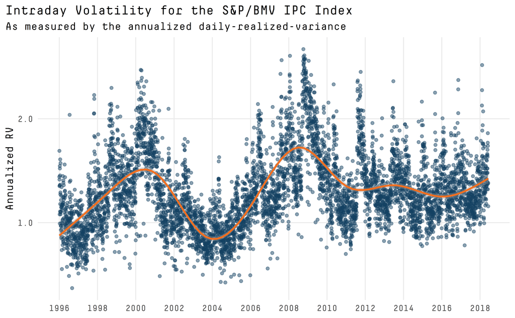

## RV Sparse

An *RV Sparse* estimator consists of calculating the realized variance but with a sample that is less frequent than the 1-minute grid. Instead, it is sampled in an *s*-minute grid (where $s \geq 1$).

We can now subset the data to a five-minute grid. We’ll call this new data `IPC_5m`.

Now we repeat the process for a $s = 10$ grid:

And then again, for the $s = 15$ grid:

And lastly, for the $s = 30$ grid:

## Volatility signature plot

The Sparse RV Estimator is calculated using an *s*-minute grid ($s \geq 1$):

$$\begin{equation}
RV_{t+1}^s = \sum \limits_{m/s}^{j=1} R^2_{t+js/m}
\end{equation}$$

This is where volatility signature plots (VSP) will help; these are a graphical tool that helps us choose the subsampling parameter $s$. We do a VSP in the following manner:

```
# A time tibble: 5,607 x 11
# Index: tidy_date
   tidy_date       RV RV_an    RVs5 RVs5_an   RVs10 RVs10_an   RVs15
   <date>       <dbl> <dbl>   <dbl>   <dbl>   <dbl>    <dbl>   <dbl>
 1 1996-01-02 3.28e-5 1.44  6.39e-5    2.01 1.02e-4     2.54 1.35e-4
 2 1996-01-03 4.50e-5 1.69  7.07e-5    2.12 1.06e-4     2.59 1.37e-4
 3 1996-01-04 3.15e-5 1.41  6.78e-5    2.07 9.99e-5     2.52 1.16e-4
 4 1996-01-05 2.88e-5 1.35  3.92e-5    1.58 5.69e-5     1.90 6.19e-5
 5 1996-01-08 1.84e-5 1.08  2.04e-5    1.14 2.87e-5     1.35 3.40e-5
 6 1996-01-09 2.90e-5 1.36  4.35e-5    1.66 5.75e-5     1.91 7.58e-5
 7 1996-01-10 3.76e-5 1.55  7.32e-5    2.16 9.70e-5     2.48 1.28e-4
 8 1996-01-11 1.55e-5 0.992 1.94e-5    1.11 2.48e-5     1.25 3.69e-5
 9 1996-01-12 3.65e-5 1.52  6.07e-5    1.96 7.28e-5     2.15 1.04e-4
10 1996-01-15 1.93e-5 1.11  2.51e-5    1.26 2.96e-5     1.37 3.97e-5
# ... with 5,597 more rows, and 3 more variables: RVs15_an <dbl>,
#   RVs30 <dbl>, RVs30_an <dbl>
```

2. Scatter plot the average RV across days on the vertical axis against $s$ on the horizontal axis.

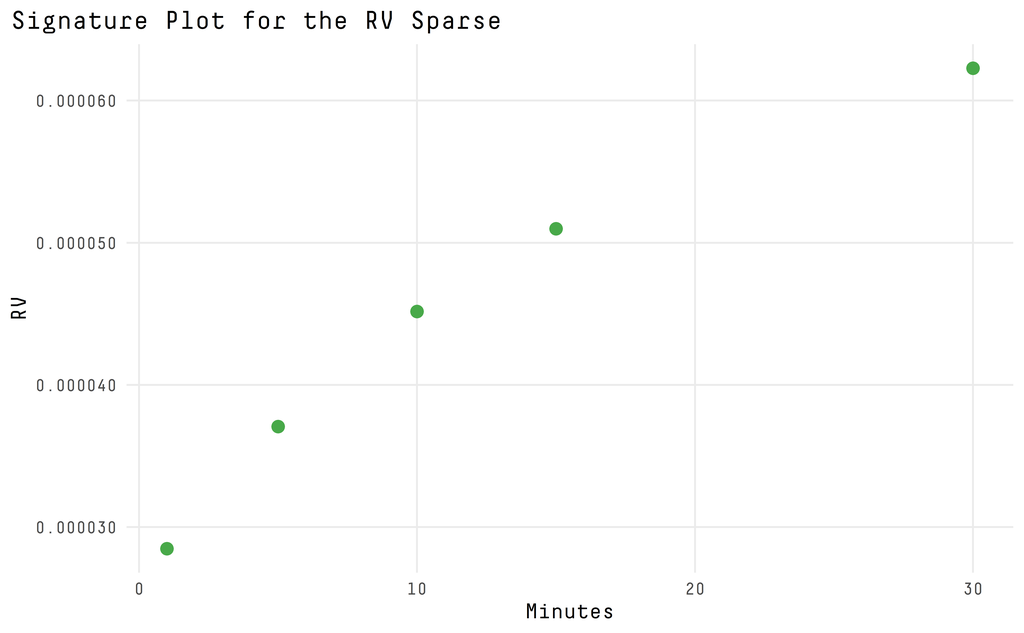

3. Look for the smallest $s$ such that the average RV does not change much for values of $s$ larger than this number.

## Average RV Estimator

We can also sample with an *s*-minute grid, but every *k* minutes. Here, we employ several combinations of these: make use of `s = 5` and `s = 10` minute samples every `k = 1` minute, and `s = 15` + `s = 30` minute samples every `k = 5` minutes. We also try `s = 15` every `k = 1` minute and `s = 10` every `k = 2`.

5-minute grid every 1-minute:

```
# A time tibble: 2,102,983 x 3
# Index: tidy_date
   tidy_date  tidy_time     ret_5m
   <date>     <time>         <dbl>
 1 1996-01-02 08:41     -0.000119
 2 1996-01-02 08:42     -0.000119
 3 1996-01-02 08:43     -0.000119
 4 1996-01-02 08:44     -0.000119
 5 1996-01-02 08:45     -0.000119
 6 1996-01-02 08:46      0
 7 1996-01-02 08:47     -0.0000432
 8 1996-01-02 08:48     -0.0000432
 9 1996-01-02 08:49     -0.0000432
10 1996-01-02 08:50     -0.0000432
# ... with 2,102,973 more rows
```

10-minute grid every 1-minute:

```
# A time tibble: 2,102,978 x 3
# Index: tidy_date
   tidy_date  tidy_time   ret_10m
   <date>     <time>        <dbl>
 1 1996-01-02 08:46     -0.000119
 2 1996-01-02 08:47     -0.000162
 3 1996-01-02 08:48     -0.000162
 4 1996-01-02 08:49     -0.000162
 5 1996-01-02 08:50     -0.000162
 6 1996-01-02 08:51      0.000292
 7 1996-01-02 08:52      0.000292
 8 1996-01-02 08:53      0.000385
 9 1996-01-02 08:54      0.000392
10 1996-01-02 08:55      0.000392
# ... with 2,102,968 more rows
```

10-minute grid every 2-minutes:

```
# A time tibble: 1,051,489 x 3
# Index: tidy_date
   tidy_date  tidy_time    ret_10m
   <date>     <time>         <dbl>
 1 1996-01-02 08:46     -0.000119
 2 1996-01-02 08:48     -0.000162
 3 1996-01-02 08:50     -0.000162
 4 1996-01-02 08:52      0.000292
 5 1996-01-02 08:54      0.000392
 6 1996-01-02 08:56      0.000446
 7 1996-01-02 08:58     -0.0000864
 8 1996-01-02 09:00      0.000418
 9 1996-01-02 09:02      0.000187
10 1996-01-02 09:04      0.000684
# ... with 1,051,479 more rows
```

15-minute grid every 1-minute:

```
# A time tibble: 2,102,973 x 3
# Index: tidy_date
   tidy_date  tidy_time   ret_15m
   <date>     <time>        <dbl>
 1 1996-01-02 08:51      0.000173
 2 1996-01-02 08:52      0.000173
 3 1996-01-02 08:53      0.000266
 4 1996-01-02 08:54      0.000274
 5 1996-01-02 08:55      0.000274
 6 1996-01-02 08:56      0.000446
 7 1996-01-02 08:57     -0.000180
 8 1996-01-02 08:58     -0.000130
 9 1996-01-02 08:59      0.000374
10 1996-01-02 09:00      0.000374
# ... with 2,102,963 more rows
```

15-minute grid every 3-minutes:

```
# A time tibble: 700,991 x 3
# Index: tidy_date
   tidy_date  tidy_time   ret_15m
   <date>     <time>        <dbl>
 1 1996-01-02 08:51      0.000173
 2 1996-01-02 08:54      0.000274
 3 1996-01-02 08:57     -0.000180
 4 1996-01-02 09:00      0.000374
 5 1996-01-02 09:03      0.000522
 6 1996-01-02 09:06      0.000885
 7 1996-01-02 09:09      0.000827
 8 1996-01-02 09:12      0.00148
 9 1996-01-02 09:15      0.000967
10 1996-01-02 09:18      0.000906
# ... with 700,981 more rows
```

15-minute grid every 5-minutes:

```
# A time tibble: 420,595 x 3
# Index: tidy_date
   tidy_date  tidy_time   ret_15m
   <date>     <time>        <dbl>
 1 1996-01-02 08:51      0.000173
 2 1996-01-02 08:56      0.000446
 3 1996-01-02 09:01      0.000479
 4 1996-01-02 09:06      0.000885
 5 1996-01-02 09:11      0.000852
 6 1996-01-02 09:16      0.000863
 7 1996-01-02 09:21      0.00151
 8 1996-01-02 09:26      0.000609
 9 1996-01-02 09:31      0.000484
10 1996-01-02 09:36     -0.00137
# ... with 420,585 more rows
```

30-minute grid every 1-minute:

```
# A time tibble: 2,102,958 x 3
# Index: tidy_date
   tidy_date  tidy_time ret_30m
   <date>     <time>      <dbl>
 1 1996-01-02 09:06     0.00106
 2 1996-01-02 09:07     0.00106
 3 1996-01-02 09:08     0.00110
 4 1996-01-02 09:09     0.00110
 5 1996-01-02 09:10     0.00110
 6 1996-01-02 09:11     0.00130
 7 1996-01-02 09:12     0.00130
 8 1996-01-02 09:13     0.00130
 9 1996-01-02 09:14     0.00134
10 1996-01-02 09:15     0.00134
# ... with 2,102,948 more rows
```

30-minute grid every 3-minutes:

```
# A time tibble: 700,986 x 3
# Index: tidy_date
   tidy_date  tidy_time ret_30m
   <date>     <time>      <dbl>
 1 1996-01-02 09:06     0.00106
 2 1996-01-02 09:09     0.00110
 3 1996-01-02 09:12     0.00130
 4 1996-01-02 09:15     0.00134
 5 1996-01-02 09:18     0.00143
 6 1996-01-02 09:21     0.00240
 7 1996-01-02 09:24     0.00126
 8 1996-01-02 09:27     0.00221
 9 1996-01-02 09:30     0.00147
10 1996-01-02 09:33     0.00101
# ... with 700,976 more rows
```

30-minute grid every 5-minutes:

```
# A time tibble: 420,592 x 3
# Index: tidy_date
   tidy_date  tidy_time    ret_30m
   <date>     <time>         <dbl>
 1 1996-01-02 09:06      0.00106
 2 1996-01-02 09:11      0.00130
 3 1996-01-02 09:16      0.00134
 4 1996-01-02 09:21      0.00240
 5 1996-01-02 09:26      0.00146
 6 1996-01-02 09:31      0.00135
 7 1996-01-02 09:36      0.000140
 8 1996-01-02 09:41     -0.0000357
 9 1996-01-02 09:46     -0.0000393
10 1996-01-02 09:51     -0.00137
# ... with 420,582 more rows
```

30-minute grid every 10-minutes:

```
# A time tibble: 210,296 x 3
# Index: tidy_date
   tidy_date  tidy_time    ret_30m
   <date>     <time>         <dbl>
 1 1996-01-02 09:06      0.00106
 2 1996-01-02 09:16      0.00134
 3 1996-01-02 09:26      0.00146
 4 1996-01-02 09:36      0.000140
 5 1996-01-02 09:46     -0.0000393
 6 1996-01-02 09:56      0.0000493
 7 1996-01-02 10:06      0.00413
 8 1996-01-02 10:16      0.00457
 9 1996-01-02 10:26      0.00437
10 1996-01-02 10:36      0.000616
# ... with 210,286 more rows
```

Now, let’s compute the RVs for each s-minute every k-minute grid:

```
# A time tibble: 5,608 x 3
# Index: tidy_date
   tidy_date         RV RV_an
   <date>         <dbl> <dbl>
 1 1996-01-02 0.000335   4.61
 2 1996-01-03 0.000350   4.71
 3 1996-01-04 0.000347   4.69
 4 1996-01-05 0.000194   3.51
 5 1996-01-08 0.000109   2.63
 6 1996-01-09 0.000236   3.87
 7 1996-01-10 0.000348   4.70
 8 1996-01-11 0.0000961  2.47
 9 1996-01-12 0.000253   4.01
10 1996-01-15 0.000134   2.91
# ... with 5,598 more rows
```